# Lab week 4 - Unsupervised methods

Data Science and Machine Learning 1 - CEU 2018

Jeno Pal

2018-01-30

## Principal Component Analysis (PCA)

We transform the coordinates of the original variables to capture as much variation as we can with independent (orthogonal) dimensions.

Scaling: necessary to have comparable units of different variables. (Multiplying a variable by 100 increases the variance and PCA would try to capture that, even though it is only an artifact of units. We don’t want that.)

We can plot observations as well as original features in the space spanned by the first two principal components.

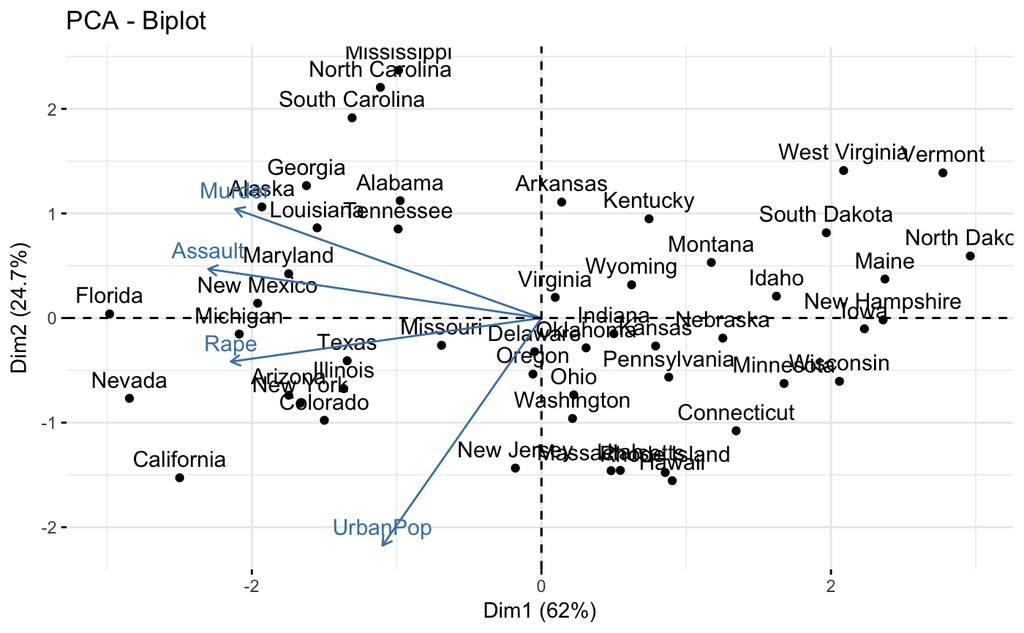

We can plot how much of total variance is captured by subsequent principal components (and in total). Total variance: if scaling was done, it equals the number of variables (since it is 1 for each variable).

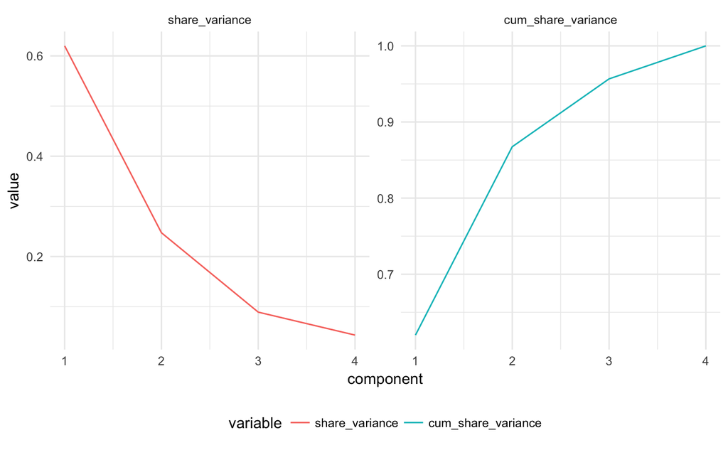

How many components summarize the data? No definite answer: decide based on sufficient variance explained.

### PCA with `caret`

We can use `preProcess` from `caret` to perform the same transformations. These can serve as inputs to `train`.

### Using PCA as an input to supervised learning

Let’s predict baseball player salaries using PCA.

Train a simple linear model:

We can use PCA with specified number of components (or we can also set the `thresh` argument to set a threshold that PCA components explain at least a certain share of the variance):

Method `pcr` implements precisely this: linear regression with principal components as explanatory variables. Its hyperparameter is the number of components to be used.

## K-means clustering

Goal: group observations that are more similar to each other than to others.

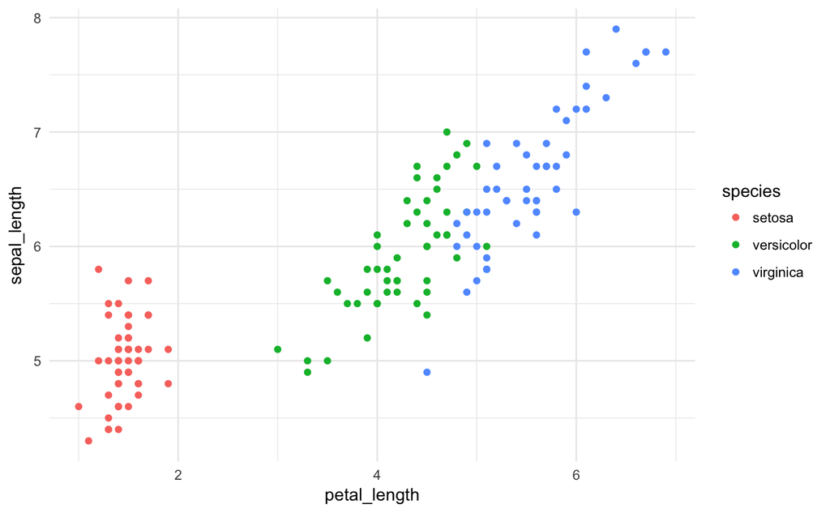

Suppose we do not know labels but want to group observations based on features.

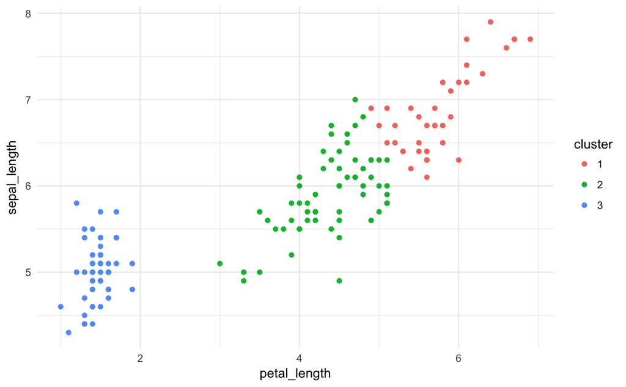

We can inspect the resulting centers.

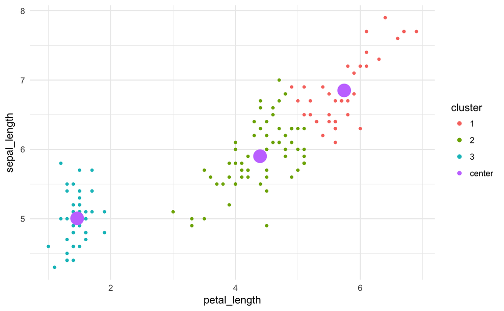

Results depend on the starting centers which are randomly chosen observations.

We should always experiment with different starting values (probably generated randomly). `nstart` controls how many times the algorithm is run with different random starting ponits for the centers. Setting it to a high value (e.g., 20) is a good idea to achieve the best groupings.

### Choosing K

There are no general rules, depends on the application. There are some rules of thumb, though. There are many, you can explore some with explanation, [here](http://www.sthda.com/english/wiki/print.php?id=239). `NbClust` calculates 30 indices based on various principles and chooses by majority rule.

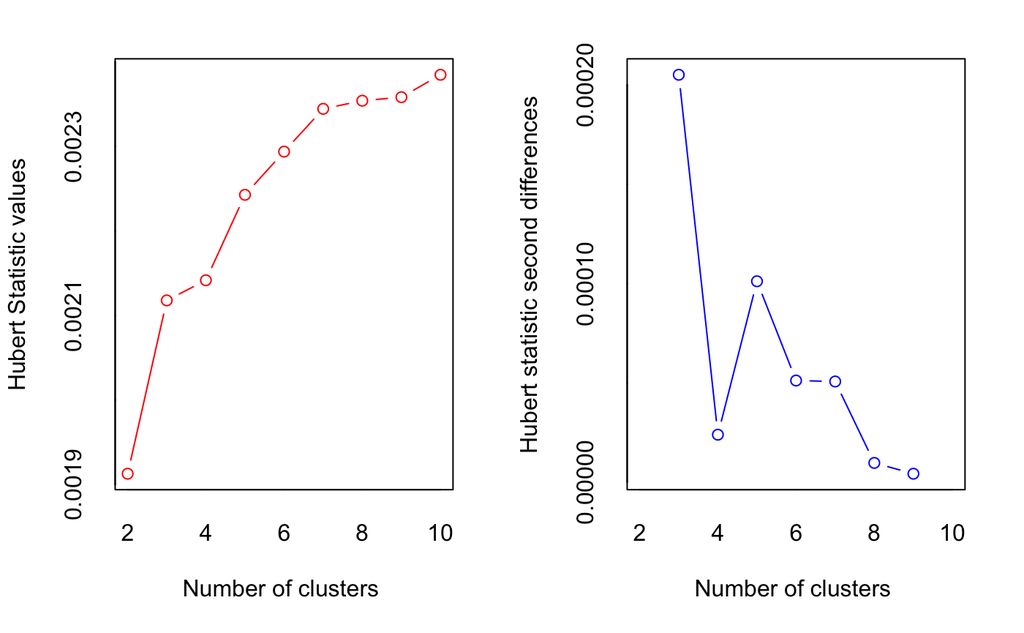

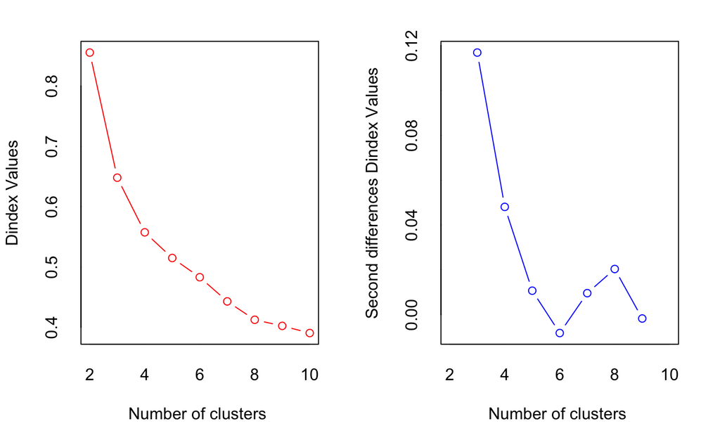

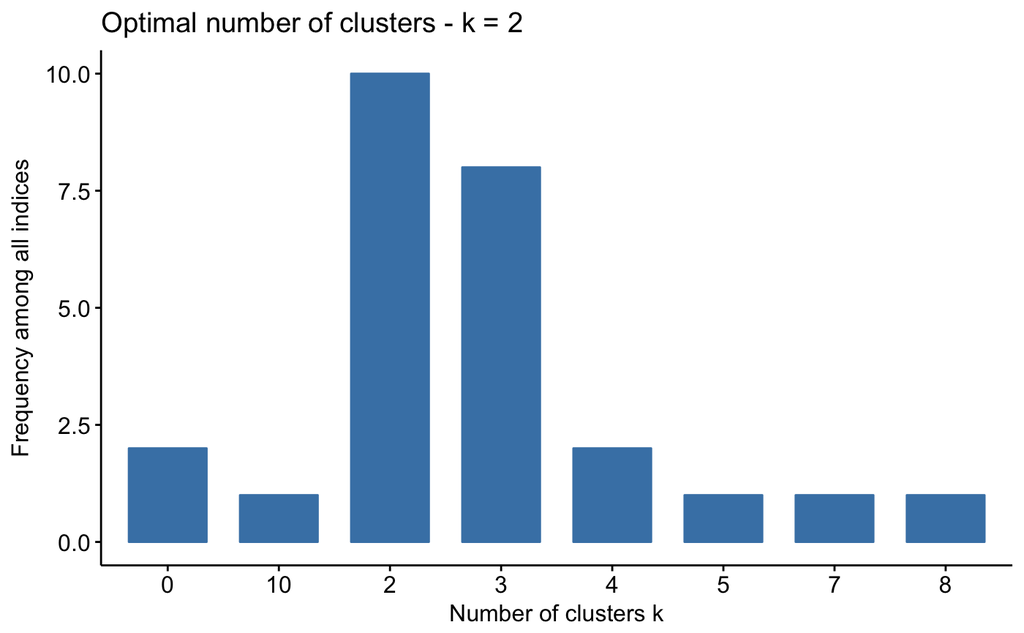

## Hierarchical clustering

With hierarchical clustering we get a nested structure of clusters based on a dissimilarity measure. Is it better than k-means? It depends - k-means does not yield a hierarchical structure. If the data does not have one in reality, hierarchical may be not as good as k-means and there are reversed situations as well.

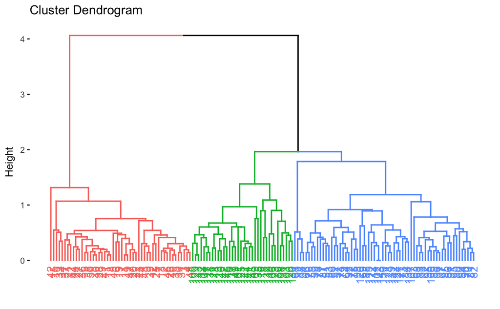

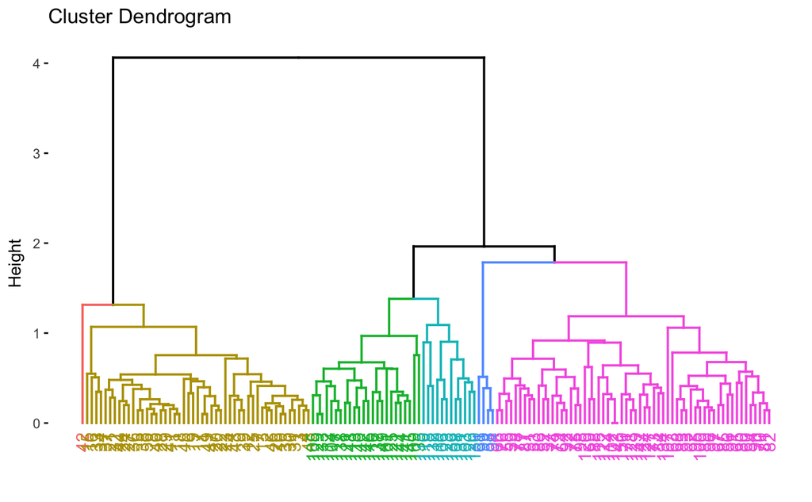

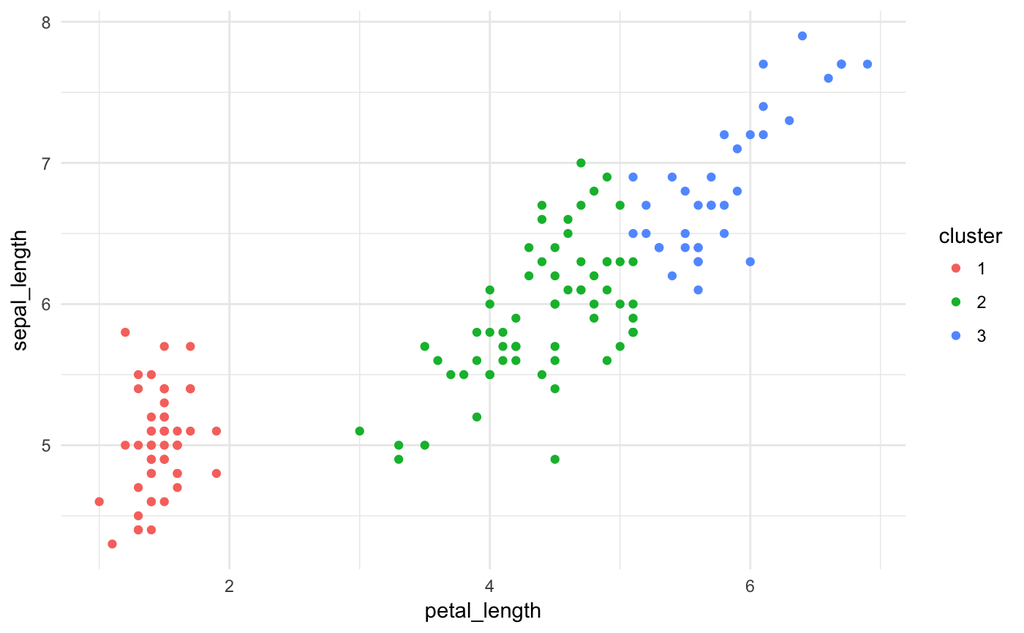

How we calculate similarities between groups may strongly affect the clustering.

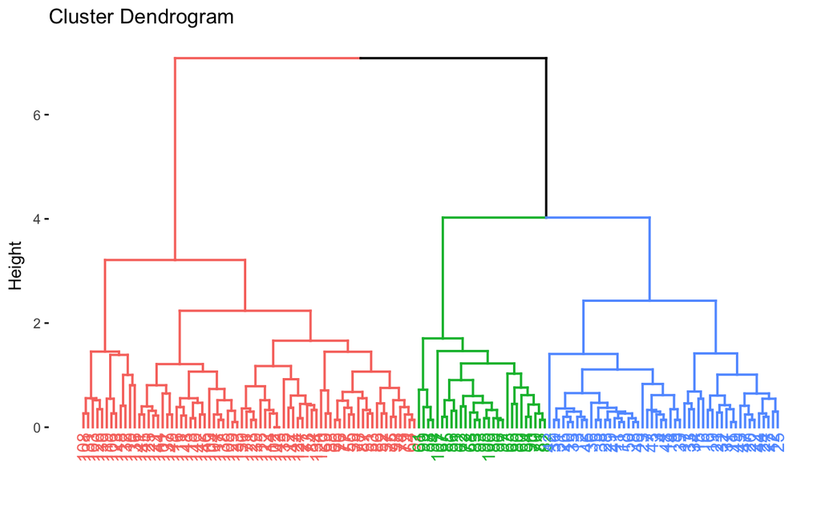

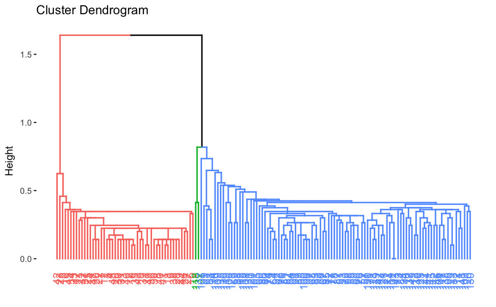

## General considerations on clustering

- as both clustering methods are based on distances in features, we may want to first bring all variables to the same scale
- clusters may be sensitive to details such as scaling or not, whether we take subsets of data or what is the dissimilarity measure in hierarchical clustering. Advice: experiment with the settings and look for consistent patterns.